# InVivoStat Dose-response Analysis

## Response and dose variables

The Resp9 response is currently being analysed by the Dose-response and Non-Linear Regression Analysis module and has been loge transformed prior to analysis.

The dose variable (Dose1) has been log10 transformed prior to analysis.

The analysis performed is a weighted non-linear regression, using 1/Response^2 as the weighting.

## Scatterplot of observed data including the predicted fit

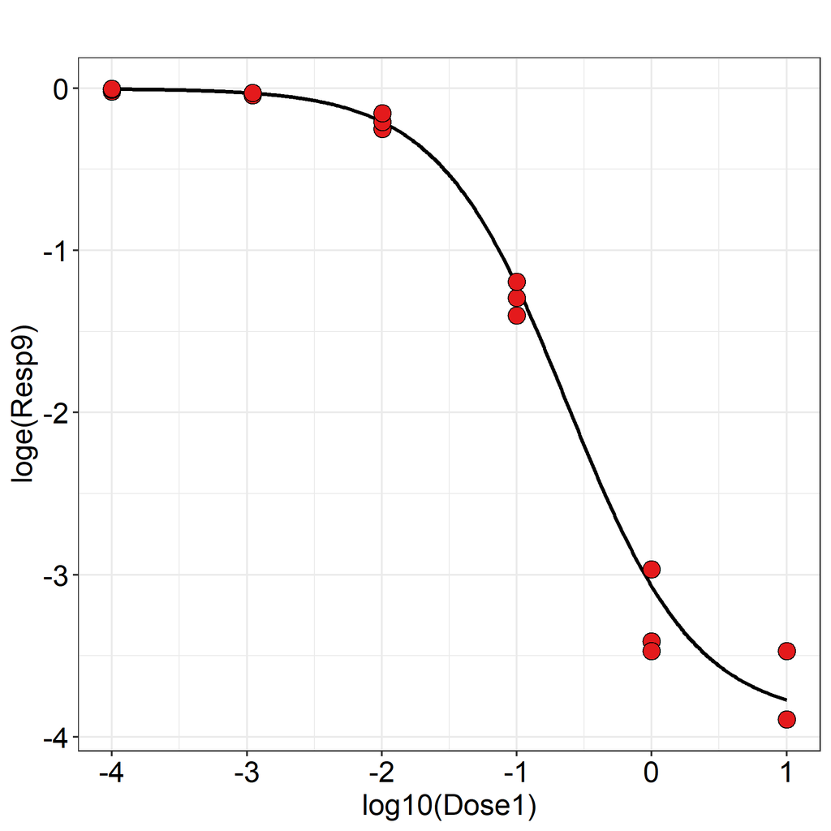

## Table of curve parameters and summary statistics

| Parameter | Estimate | Std error | t-value | p-value |
| --- | --- | --- | --- | --- |
| A | -3.894 | 0.540 | -7.21 | < 0.0001 |
| B | 0.915 | 0.079 | 11.59 | < 0.0001 |
| C | -0.625 | 0.174 | -3.59 | 0.0029 |
| D | -0.003 | 0.002 | -1.90 | 0.0778 |

## Back-transformed ED50 estimate with 95% confidence intervals

|  | ED50 | Lower 95% CI | Upper 95% CI |
| --- | --- | --- | --- |
| Estimate | 0.237 | 0.100 | 0.559 |

## Description of the analysis results

The data was analysed using non-linear regression. The estimate of the minimum of the curve is -3.894. The estimate of the maximum of the curve is -0.003. The estimate of the slope coefficient of the curve is 0.915. The estimate of the logED50 of the curve is -0.625. The back-transformed estimate of the ED50 of the curve is 0.237.

For more information on the theoretical approaches that are implemented within this module, see Bate and Clark (2014).

## Scatterplot of responses and quality control (QC) samples

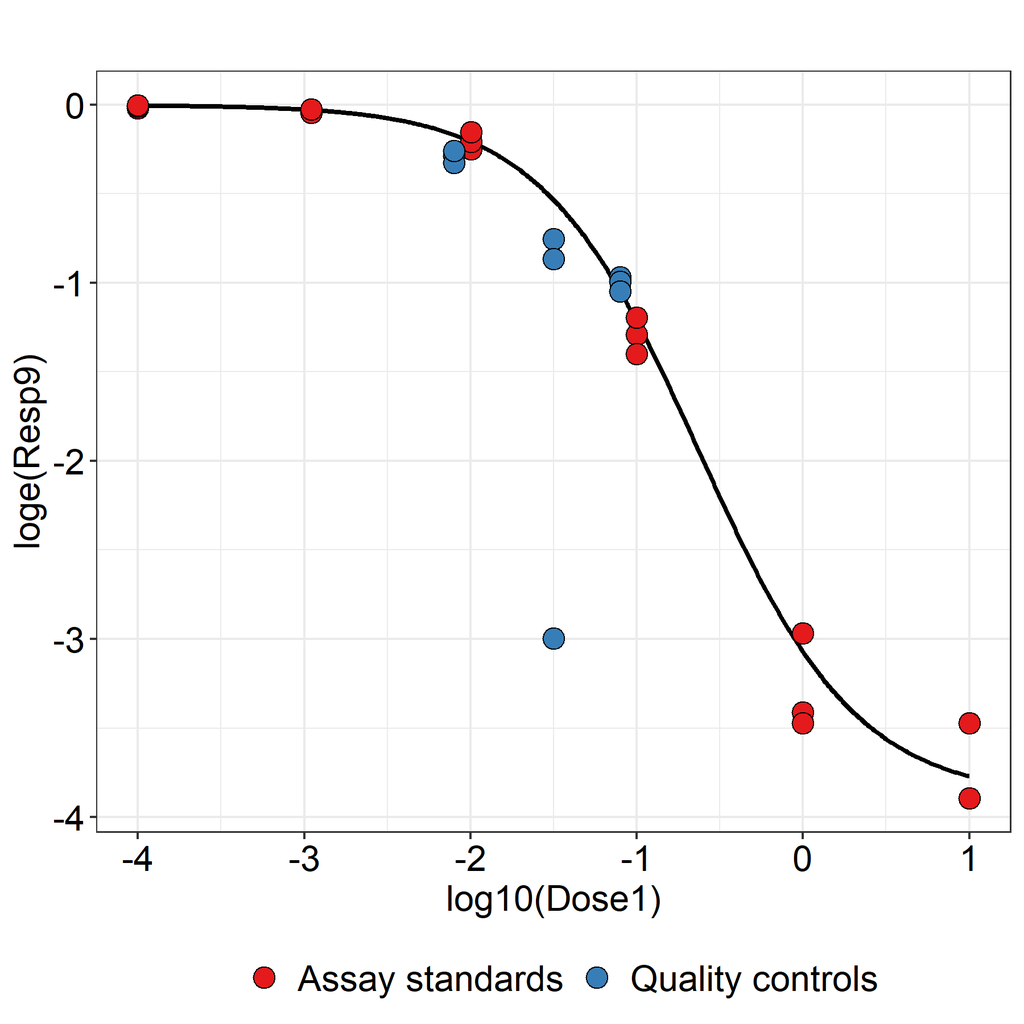

## Table of QC summary statistics

| QC ID number | True QC mean | Back-calculated QC mean | Std dev of back-calculated QC mean | No. of back-calculated QCs | Relative error (%) | Coefficient of variation (%) |
| --- | --- | --- | --- | --- | --- | --- |
| 1 | 0.008 | 0.015 | 0.001 | 3 | 87.28 | 9.16 |
| 2 | 0.032 | 0.138 | 0.350 | 3 | 336.97 | 253.08 |
| 3 | 0.079 | 0.074 | 0.003 | 3 | -6.58 | 4.06 |

Note: The relative error (%) and coefficient of variation (%) for an individual QC are only reliable statistics if all the QCs can be back-calculated.

## Back-calculated sample responses

| Sample ID number | Sample response | Back-calculated response |
| --- | --- | --- |
| 1 | -1.6094379124341 | 0.161 |
| 2 | -0.510825623765991 | 0.030 |
| 3 | -0.916290731874155 | 0.065 |
| 4 | -1.6094379124341 | 0.161 |
| 5 | -0.609725572420873 | 0.037 |
| 6 | -0.392238467057173 | 0.021 |
| 7 | -0.131818574620848 | 0.006 |
| 8 | -1.46101790731583 | 0.135 |
| 9 | -0.0100503358535015 | 0.000 |
| 10 | -3.91202300542815 | NaN |
| 11 | -4.60517018598809 | NaN |

## References

When referring to InVivoStat, please cite 'InVivoStat, version 5.2.0'.

Bate, S.T. and Clark, R.A. (2014). The Design and Statistical Analysis of Animal Experiments. Cambridge University Press.